# Regression Analysis

Monika Peteva Petkova

mpetevap@uni-sofia.bg, monikapetevapetkova@gmail.com

2021

# Simple Linear Regression Model

In this topic we assume that $\mathbb{D}X < \infty$ and $\mathbb{D}Y < \infty$.

Regression analysis study the form of the relationship between two numerical random variables $X$ and $Y$. More precisely its aim is by knowing $X$ and the regression model to predict $Y$.

$X$ is called **independent variable (or predictor) /независима променлива/**.

$Y$ is called **dependent (or outcome) variable /зависима променлива/**.

When there is a single dependent variable and a single independent variable, and the dependence on the coefficients is linear the analysis is called **a simple linear regression analysis /проста линейна регресия/**. More precisely **the simple linear regression model** is

$$Y = \hat{Y} + \varepsilon = \beta_0 + \beta_1 X + \varepsilon$$
where

- **$\varepsilon$ is the random error term /случайна грешка/**.
  $$\epsilon = Y - \hat{Y} = Y - \beta_0 - \beta_1 X.$$
- $\beta_0$, $\beta_1$ are unknown coefficients. They will be estimated from the data by using **the method of least squares /метода на най-малките квадрати/** (by minimizing the sum of square errors $\sum_{i=1}^n \varepsilon_i^2$).

By assumption

- $\mathbb{E}\varepsilon = 0$ (and therefore $\mathbb{E}Y = \beta_0 + \beta_1 \mathbb{E}X$.)
- $cor(X, \varepsilon) = 0,$ i.e. the independent variable $X$ and the random error term $\varepsilon$ are uncorrelated.

Therefore, $\hat{Y}$ and $\varepsilon$ are uncorrelated and
$$\mathbb{E}(\varepsilon|X) = \mathbb{E}\varepsilon = 0, \,\,\mathbb{D}(\varepsilon|X) = \mathbb{D}\varepsilon = \sigma_\varepsilon^2.$$
$$\hat{Y} = \mathbb{E}(Y | X) = \beta_0 + \beta_1 X$$
and the corresponding **simple linear regression equation** (the equation of the corresponding straight line) is as follows:
$$y = \beta_0 + \beta_1 x$$

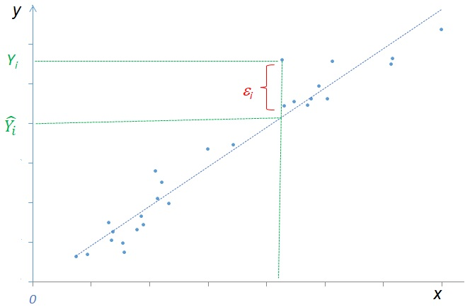

By the model assumed it is easy to see that

- $\beta_0 = E(Y|X = 0)$ is the **intercept** of the regression line from $Oy$ axis.
- $\beta_1 = E(Y|X+1) - E(Y|X) = \beta_0 + \beta_1(X + 1) - \beta_0 - \beta_1 X$ is the **slope** - the expected increment of the $Y$ (in its units) when $X$ increases with $1$ (in the units of $X$).

For $\beta_1 > 0$, when $X$ increases $Y$ gets bigger.

For $\beta_1 < 0$, when $X$ increases $Y$ gets smaller.

For $\beta_1 = 0$, $X$ does not influence $Y$.

When we consider the variances $\mathbb{D}(\hat{Y}) = \mathbb{D}(\beta_0 + \beta_1 X) = \beta_1^2 \mathbb{D}X$,

$$\mathbb{D}(Y) = \mathbb{D}(\hat{Y} + \varepsilon) = \mathbb{D}(\hat{Y}) + \mathbb{D}\varepsilon = \beta_1^2 \mathbb{D}X + \sigma_\varepsilon^2$$

$$cor^2(Y, \hat{Y}) = \frac{cov^2(Y, \hat{Y})}{\mathbb{D}(Y)\mathbb{D}(\hat{Y})} = \frac{cov^2(Y, \beta_0 + \beta_1 X)}{\mathbb{D}Y(\beta_1^2\mathbb{D}X)} = \frac{(cov(Y, \beta_1 X))^2}{\mathbb{D}Y\beta_1^2\mathbb{D}X}$$
$$= \frac{(\beta_1 cov(Y, X))^2}{\mathbb{D}Y\beta_1^2\mathbb{D}X} = \frac{cov^2(Y, X)}{\mathbb{D}Y\mathbb{D}X} = cor^2(Y,X)$$
Moreover,
$$cor^2(Y, \hat{Y}) = \frac{cov^2(Y, \hat{Y})}{\mathbb{D}Y\mathbb{D}\hat{Y}} = \frac{cov^2(\hat{Y} + \varepsilon, \hat{Y})}{\mathbb{D}Y\mathbb{D}\hat{Y}} = \frac{(cov(\hat{Y},\hat{Y}) + cov(\varepsilon, \hat{Y}))^2}{\mathbb{D}Y\mathbb{D}\hat{Y}}$$
$$= \frac{(\mathbb{D}\hat{Y} + 0)^2}{\mathbb{D}Y \mathbb{D}\hat{Y}} = \frac{\mathbb{D}\hat{Y}}{\mathbb{D}Y} = 1 - \frac{\mathbb{D}\varepsilon}{\mathbb{D}Y} = \beta_1^2 \frac{\mathbb{D}X}{\mathbb{D}Y}$$

It can be shown that the minimal value of the mean square error between $Y$ and $\hat{Y}$ can be obtained for
$$\beta_0 = \mathbb{E}Y - \beta_1 \mathbb{E}X \quad (see\,\, the \,\,assumptions \,\,for \,\,\varepsilon)$$

$$\beta_1 = \sqrt{\frac{\mathbb{D}Y}{\mathbb{D}X}}cor(X,Y) = \frac{cor(X,Y)\sqrt{\mathbb{D}X\mathbb{D}Y}}{\mathbb{D}X} = \frac{cov(X,Y)}{\mathbb{D}X}$$
The corresponding estimators of $\mathbb{E}Y$, $\mathbb{E}X$, $\mathbb{D}Y$, $\mathbb{D}X$, $cov(X,Y)$ and $cor(X,Y)$ are already known. Therefore, we can estimate $\beta_0$ and $\beta_1$.

When we use these coefficients, the minimal value of the **Residual Standard error** of the model is (between $Y$ and $\hat{Y}$) is
$$\sigma_\varepsilon = \sqrt{\mathbb{D}\varepsilon} = \sqrt{\mathbb{E}\varepsilon^2} = \sqrt{\mathbb{E}(Y - \hat{Y})^2} =$$
$$= \sqrt{\mathbb{E}(Y - \beta_0 - \beta_1X)^2} = \sqrt{\mathbb{D}Y(1-cor^2 (X,Y))}$$
The coefficient
$$cor^2(X,Y) = 1 - \frac{\mathbb{D}\varepsilon}{\mathbb{D}Y},$$
(and the corresponding estimator $R^2$) is called **coefficient of determination /коефициент на определеност/**. And, as far as and
$$\mathbb{D}Y =\mathbb{D}Ycor^2(X,Y) + \mathbb{D}\varepsilon = \mathbb{D}\hat{Y} + \mathbb{D}\varepsilon$$
$cor^2(X,Y)$ shows what part of $\mathbb{D}Y$ which is due to regression.

$1 - cor^2(X,Y)$ is called **coefficient of indetermination /коефициент на неопределеност/**. It shows part of $\mathbb{D}Y$ is due to changes of the error term, i.e. variables that are not considered in the model.

The inequality
$$\mathbb{D}(Y|X = x) = \mathbb{D}(\beta_0 + \beta_1 X + \varepsilon|X = x) = \sigma_\varepsilon^2 \leq \beta_1^2 \mathbb{D}X + \sigma_\varepsilon^2 = \mathbb{D}Y$$
means that the information for $X$ can help us to improve the estimation for $Y$ as far as by using $X$ we will obtain shorter confidence intervals for $\mathbb{E}(Y|X)$.

Suppose that we have i.i.d. observations on the random vector $(X,Y)$. As far as the last means that
$$Y_i = \hat{Y}_i + \varepsilon_i = \beta_0 + \beta_1 X_i + \varepsilon_i$$
$$\hat{Y}_i = \mathbb{E}(Y_i | X_i) = \beta_0 + \beta_1 X_i , \quad i = 1, 2, \ldots, n$$
we actually assume that
$$cor(\varepsilon_i, \varepsilon_j) = 0,\,\,1 \leq i < j \leq n$$

and

$$\mathbb{D}\varepsilon_i = \sigma_\varepsilon^2, \quad i = 1, 2, \ldots, n$$
The last requirement is called **homoscedasticity /хомоскедастичност/**. If we have different variances of the error terms we speak about **heteroscedasticity /хетероскедастичност/**.

The corresponding **Estimator of the Residual Standard error (RSE) /Стандартна грешка на остатъците/** is
$$\hat{\sigma}_\varepsilon = RSE = S_\varepsilon = \sqrt{\frac{\sum_{i=1}^n\varepsilon_i^2}{n-r-1}} = \sqrt{\frac{\sum_{i=1}^n\varepsilon_i^2}{n-2}},$$
where $r$ is the last subindex of the unknown coefficients $\beta_0, \beta_1$ in the regression line. In this case $r = 1$. Or in the denominator we have the sample size minus the number of the unknown coefficients. Usually $S_\varepsilon^2$ is called **mean square error(MSE) of the model** and we use the following notations
$$SSE = \sum_{i=1}^n\varepsilon_i^2, \quad MSE = \frac{SSE}{n-r-1} = RSE^2 = S_\varepsilon^2$$
MSE is unbiased estimator of $\sigma_{\varepsilon}^2$.

The most important case of these models is when the errors $\varepsilon_i$ are i.i.d $\varepsilon_i \in N(0, \sigma_\varepsilon^2)$. Then,
$$(Y|X = x) = (\beta_0 + \beta_1 X + \varepsilon|X = x)$$
$$\in N\left(\beta_0 + \beta_1 x = \mathbb{E}Y + cor(X,Y)\sqrt{\frac{\mathbb{D}Y}{\mathbb{D}X}}(x - \mathbb{E}X); \sigma_\varepsilon^2 = \mathbb{D}Y(1-cor^2 (X,Y))\right)$$
and knowing $X$, $\beta_0$ and $\beta_1$ we can construct confidence interval for the expected value $\mathbb{E}(Y|X = x)$.

Let us note that another simple linear regression models are:

$\checkmark Y = \beta_0 + \beta_1f(X) + \varepsilon$;

$\checkmark g(Y) = \beta_0 + \beta_1X + \varepsilon$.

We work with them via substitutions.

Let us now explain briefly **the method of least squares /метод на най-малките квадрати/** which is the best way to estimate the coefficients. We are looking for two constants
$$(\beta_0, \beta_1) = argmin \left(\sum_{i=1}^n \varepsilon_i^2\right) = argmin\left(\sum_{i=1}^n(Y_i - \hat{Y_i})^2\right) = argmin\left(\sum_{i=1}^n(Y_i - (b_0 + b_1 X_i))^2\right)$$
The solution is obtained when we solve the system of equations
$$\left|\begin{array}{ccc}
\frac{\partial}{\partial b_0}\sum_{i=1}^n(b_0 + b_1 X_i - Y_i)^2 & = & 0\\
\frac{\partial}{\partial b_1}\sum_{i=1}^n(b_0 + b_1 X_i - Y_i)^2 & = & 0\\
\end{array}
\right.$$

$$\left|\begin{array}{ccc}
2\sum_{i=1}^n(b_0 + b_1 X_i - Y_i) & = & 0\\
2\sum_{i=1}^n(b_0 + b_1 X_i - Y_i)X_i & = & 0\\
\end{array}
\right.$$
$$\left|\begin{array}{ccc}
nb_0 + b_1\sum_{i=1}^n X_i & = & \sum_{i=1}^n Y_i\\
b_0 \sum_{i=1}^nX_i + b_1 \sum_{i=1}^nX_i^2 & = & \sum_{i=1}^n X_iY_i\\
\end{array}
\right.$$
$$\left|\begin{array}{ccc}
b_0 + b_1\bar{X}_n & = & \bar{Y}_n\\
b_0 \bar{X}_n + b_1 \frac{\sum_{i=1}^nX_i^2}{n} & = & \frac{\sum_{i=1}^n X_iY_i}{n}\\
\end{array}
\right.$$

Intercept:
$$b_0 = \bar{Y}_n - b_1 \bar{X}_n$$

Slope:

$$b_1 = \frac{\sum_{i=1}^n(X_i - \bar{X}_n)(Y_i - \bar{Y}_n)}{\sum_{i=1}^n(X_i - \bar{X}_n)^2}$$

It can be performed by using the function $lm$ in R.